# Схема аутентификации пользователей с помощью логинов и паролей.

Казначеев С. И.

Российский университет дружбы народов, Москва, Россия

# Информация

## Докладчик

[figure not shown]

- Казначеев Сергей Ильич
- Студент
- Российский университет дружбы народов
- [1132240693@pfur.ru]

# Вводная часть

## Введение

- Аутентификация — фундамент информационной безопасности
- От простых паролей к многофакторным системам
- Особенности российских разработок

[figure not shown]

## Объект и предмет исследования

1. 1960-1970-е: Эпоха мейнфреймов

БЭСМ-6 с ОС “Диспетчер-68”

Примитивные парольные схемы

Хранение в защищённых областях памяти

Контроль доступа к вычислительным задачам

2. 1970-1980-е: Мини-ЭВМ

Системы РТ-11 и ДИАЛ

Первое файловое хранение учётных записей

Базовое шифрование паролей

Разграничение прав доступа к устройствам

3. 1980-1990-е: UNIX-революция

ОС ДЕМОС (адаптация BSD UNIX)

Классическая модель /etc/passwd

Поддержка кириллицы в логинах

Механизмы блокировки при bruteforce

4. 2000-е → настоящее время: Современные ОС

Astra Linux / ALT Linux

ГОСТ-шифрование паролей

Модульная PAM-аутентификация

Многофакторные методы (токены, 2FA)

[figure not shown]

## Ранние советские ОС (1960-1970)

Характеристики

- Элементарные парольные схемы
- Хранение в защищенных областях памяти
- Пример: ОС “Диспетчер-68” для БЭСМ-6

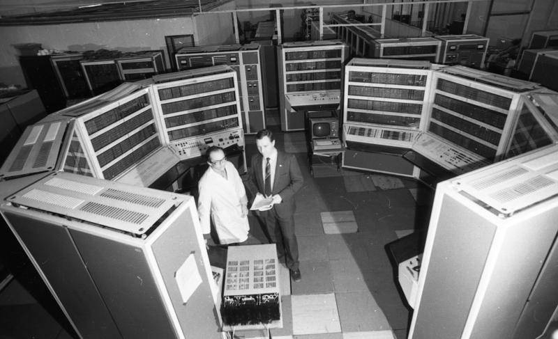

## Эпоха мини-ЭВМ (1970-1980)

Нововведения

- Файловое хранение учетных записей
- Базовое шифрование паролей
- Разграничение доступа к устройствам

[figure not shown]

## UNIX-подобные системы (1980-1990)

Особенности ДЕМОС

- Адаптация /etc/passwd
- Поддержка кириллицы
- Механизмы блокировки при bruteforce

[figure not shown]

## Современные угрозы и защита

Основные вызовы безопасности

- Атаки методом перебора (Bruteforce)

Автоматизированные системы подбора паролей

Защита лимиты попыток входа, CAPTCHA

- Фишинг и социальная инженерия

Кража учетных данных через поддельные формы

Защита двухфакторная аутентификация

- Уязвимости в компонентах

Эксплуатация слабостей PAM-модулей

Защита регулярные обновления и аудит

[figure not shown]

## Современные угрозы и защита

Защитные механизмы

- Жесткие политики паролей
- Многофакторная аутентификация
- Непрерывный мониторинг

[figure not shown]

## Будущее

Что нас ждет?

- Распознавание лиц и голоса
- “Невидимая” аутентификация
- Квантовая криптография

[figure not shown]

## Итоги

Что важно запомнить?

- Постоянное развитие методов
- Соответствие мировым стандартам
- Уникальные российские решения